# Data Visualization - badge

LASER Institute Foundation Learning Lab 3

Meiko Lin

2022-07-14

[figure not shown]

The final activity for each learning lab provides space to work with data and to reflect on how the concepts and techniques introduced in each lab might apply to your own research.

To earn a badge for each lab, you are required to respond to a set of prompts for two parts:

- In Part I, you will reflect on your understanding of key concepts and begin to think about potential next steps for your own study.
- In Part II, you will create a simple data product in R that demonstrates your ability to apply a data analysis technique introduced in this learning lab.

### Part I: Reflect and Plan

Use the institutional library (e.g. [NCSU Library](https://www.lib.ncsu.edu/#articles)), [Google Scholar](https://scholar.google.com/) or search engine to locate a research article, presentation, or resource that applies learning analytics analysis to an educational context or topic of interest. More specifically, **locate a study that makes use of one of the data structures we learned today.** You are also welcome to select one of your research papers.

1. Provide an APA citation for your selected study.
   - Ahn, J., Nguyen, H., Campos, F. & Young, W. (April, 2021). *Proceedings of the 11<sup>th</sup> annual LAK international Learning Analytics and Knowledge Conference*.
2. What educational issue, “problem of practice,” and/or questions were addressed?
   - To explore more efficient ways to process such everyday varieties of information into analytics that are more usable and practical for educators.
3. What are some common approaches EDA approaches used and what did they entail?
   - The authors described the potential efficacy of design decisions such as screening the crowd and asking the crowd to explain their answers. They also explored the potential of crowdsourcing as a learning opportunity.
4. How were data visualization or feature engineering used to support analysis, if at all?What were the key findings or conclusions?
   - Visualization was used to provide multimedia instructions
5. Finally, what value, if any, might education practitioners find in these results?
   - This work offered design implications for leveraging crowdsourcing to process educational data in ways that are relevant to educators.

Draft a new research question of guided by the the phases of the Learning Anlytics Workflow. Or use one of your current research questions.

1. What educational issue, “problem of practice,” and/or questions is addressed??
   - How do educators conceptualize social and emotional learning?
2. Briefly describe any steps of the EDA approach that will be used..
   - Apply a supervised ML techniques (trained via an existing coded data) to the focus group data.
3. What elements of EDA might require human judgement and decision making?
   - Human judgement will be required to verify how well the ML model code the focus group data (e.g. Is the text coded accurately?)\

### Part II: Data Product

In our Learning Analytics code-along, we only scratched the surface on the number of ways that we can wrangle the data.

Using one of the data sets provided in the data folder, your goal for this lab is to extend the Data Visualizations using `ggplot` for Learning Analytics. You have three options for completing the Data Product portion: You can create the visualization exercise provided. Create a visualization of your choice using a data set from the data folder Create a visualization using your own data.

I highly recommend creating a new R script in your lab-3 folder to complete this task. When your code is ready to share, use the code chunk below to share the final code for your model and answer the questions that follow.

```r
#load libraries
library(tidyverse)
library(here)
#import data
sci_data <- read_csv(here("data", "sci-online-classes.csv"))
#skim data:  Presents summarized details about variables
library(skimr)
skim(sci_data)
```

Data summary

| Name | sci_data |
| --- | --- |
| Number of rows | 603 |
| Number of columns | 30 |
| _______________________ |  |
| Column type frequency: |  |
| character | 6 |
| logical | 1 |
| numeric | 23 |
| ________________________ |  |
| Group variables | None |

**Variable type: character**

| skim_variable | n_missing | complete_rate | min | max | empty | n_unique | whitespace |
| --- | --- | --- | --- | --- | --- | --- | --- |
| course_id | 0 | 1 | 12 | 13 | 0 | 26 | 0 |
| subject | 0 | 1 | 4 | 5 | 0 | 5 | 0 |
| semester | 0 | 1 | 4 | 4 | 0 | 3 | 0 |
| section | 0 | 1 | 2 | 2 | 0 | 4 | 0 |
| Gradebook_Item | 0 | 1 | 9 | 35 | 0 | 3 | 0 |
| Gender | 0 | 1 | 1 | 1 | 0 | 2 | 0 |

**Variable type: logical**

| skim_variable | n_missing | complete_rate | mean | count |
| --- | --- | --- | --- | --- |
| Grade_Category | 603 | 0 | NaN | : |

**Variable type: numeric**

| skim_variable | n_missing | complete_rate | mean | sd | p0 | p25 | p50 | p75 | p100 | hist |
| --- | --- | --- | --- | --- | --- | --- | --- | --- | --- | --- |
| student_id | 0 | 1.00 | 86069.54 | 10548.60 | 43146.00 | 85612.50 | 88340.00 | 92730.50 | 97441.00 | ▁▁▁▃▇ |
| total_points_possible | 0 | 1.00 | 4274.41 | 2312.74 | 840.00 | 2809.50 | 3583.00 | 5069.00 | 15552.00 | ▇▅▂▁▁ |
| total_points_earned | 0 | 1.00 | 3244.69 | 1832.00 | 651.00 | 2050.50 | 2757.00 | 3875.00 | 12208.00 | ▇▅▁▁▁ |
| percentage_earned | 0 | 1.00 | 0.76 | 0.09 | 0.34 | 0.70 | 0.78 | 0.83 | 0.91 | ▁▁▃▇▇ |
| FinalGradeCEMS | 30 | 0.95 | 77.20 | 22.23 | 0.00 | 71.25 | 84.57 | 92.10 | 100.00 | ▁▁▁▃▇ |
| Points_Possible | 0 | 1.00 | 76.87 | 167.51 | 5.00 | 10.00 | 10.00 | 30.00 | 935.00 | ▇▁▁▁▁ |
| Points_Earned | 92 | 0.85 | 68.63 | 145.26 | 0.00 | 7.00 | 10.00 | 26.12 | 828.20 | ▇▁▁▁▁ |
| q1 | 123 | 0.80 | 4.30 | 0.68 | 1.00 | 4.00 | 4.00 | 5.00 | 5.00 | ▁▁▂▇▇ |
| q2 | 126 | 0.79 | 3.63 | 0.93 | 1.00 | 3.00 | 4.00 | 4.00 | 5.00 | ▁▂▆▇▃ |
| q3 | 123 | 0.80 | 3.33 | 0.91 | 1.00 | 3.00 | 3.00 | 4.00 | 5.00 | ▁▃▇▅▂ |
| q4 | 125 | 0.79 | 4.27 | 0.85 | 1.00 | 4.00 | 4.00 | 5.00 | 5.00 | ▁▁▂▇▇ |
| q5 | 127 | 0.79 | 4.19 | 0.68 | 2.00 | 4.00 | 4.00 | 5.00 | 5.00 | ▁▂▁▇▅ |
| q6 | 127 | 0.79 | 4.01 | 0.80 | 1.00 | 4.00 | 4.00 | 5.00 | 5.00 | ▁▁▃▇▅ |
| q7 | 129 | 0.79 | 3.91 | 0.82 | 1.00 | 3.00 | 4.00 | 4.75 | 5.00 | ▁▁▅▇▅ |
| q8 | 129 | 0.79 | 4.29 | 0.68 | 1.00 | 4.00 | 4.00 | 5.00 | 5.00 | ▁▁▂▇▆ |
| q9 | 129 | 0.79 | 3.49 | 0.98 | 1.00 | 3.00 | 4.00 | 4.00 | 5.00 | ▁▃▇▇▃ |
| q10 | 129 | 0.79 | 4.10 | 0.93 | 1.00 | 4.00 | 4.00 | 5.00 | 5.00 | ▁▂▃▇▇ |
| TimeSpent | 5 | 0.99 | 1799.75 | 1354.93 | 0.45 | 851.90 | 1550.91 | 2426.09 | 8870.88 | ▇▅▁▁▁ |
| TimeSpent_hours | 5 | 0.99 | 30.00 | 22.58 | 0.01 | 14.20 | 25.85 | 40.43 | 147.85 | ▇▅▁▁▁ |
| TimeSpent_std | 5 | 0.99 | 0.00 | 1.00 | -1.33 | -0.70 | -0.18 | 0.46 | 5.22 | ▇▅▁▁▁ |
| int | 76 | 0.87 | 4.22 | 0.59 | 2.00 | 3.90 | 4.20 | 4.70 | 5.00 | ▁▁▃▇▇ |
| pc | 75 | 0.88 | 3.61 | 0.64 | 1.50 | 3.00 | 3.50 | 4.00 | 5.00 | ▁▁▇▅▂ |
| uv | 75 | 0.88 | 3.72 | 0.70 | 1.00 | 3.33 | 3.67 | 4.17 | 5.00 | ▁▁▆▇▅ |

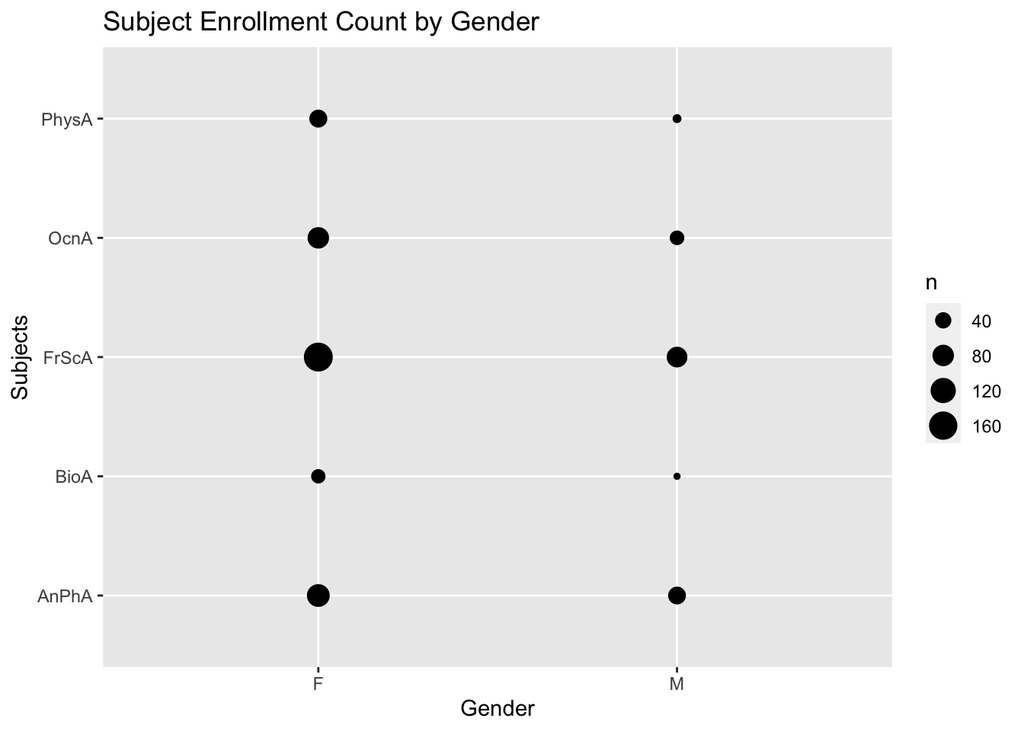

```r
#ggplot
library(ggplot2)
#layer 1: add data and aesthetics mapping
ggplot(sci_data,
       aes(x = Gender,
           y = subject)) +
#layer 2: +  geom function type
  geom_count() +
#layer 3: add lables
  labs(title="Subject Enrollment Count by Gender", x="Gender", y = "Subjects")
```

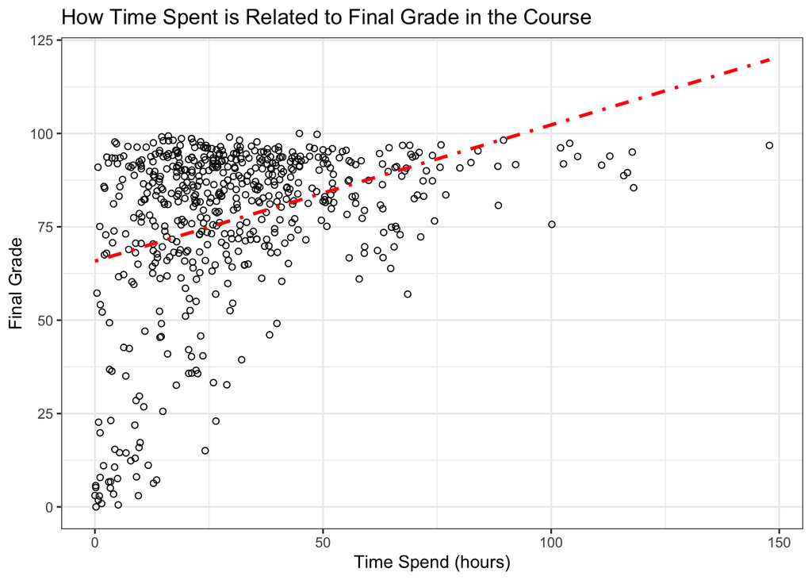

```r
#layer 1: add data and aesthetics mapping
ggplot(sci_data,
       aes(x = TimeSpent_hours,
           y = FinalGradeCEMS)) +
#layer 2:  geom function type
  geom_point(shape=1) +
#layer 3: add a regression line
  stat_smooth(method = "lm",
              formula = y ~ x,
              geom = "smooth",
              se=F,
              color="red",
              linetype="dotdash") +
#layer 4: add lables
  labs(title="How Time Spent is Related to Final Grade in the Course", x="Time Spend (hours)", y = "Final Grade") +
  theme_bw()
```

### Knit & Submit

Congratulations, you’ve completed your Foundation Badge on Learning Analytics Workflow! Complete the following steps to submit your work for review by:

1. Change the name of the author: in the [YAML header](https://monashdatafluency.github.io/r-rep-res/yaml-header.html) at the very top of this document to your name. As noted in [Reproducible Research in R](https://monashdatafluency.github.io/r-rep-res/index.html), The YAML header controls the style and feel for knitted document but doesn’t actually display in the final output.
2. Click the yarn icon above to “knit” your data product to a [HTML](https://bookdown.org/yihui/rmarkdown/html-document.html) file that will be saved in your R Project folder.
3. Commit your changes in GitHub Desktop and push them to your online GitHub repository.
4. Publish your HTML page the web using one of the following [publishing methods](https://rpubs.com/cathydatascience/518692): Publish on [RPubs](https://rpubs.com/) by clicking the “Publish” button located in the Viewer Pane when you knit your document. Note, you will need to quickly create a RPubs account. Publishing on GitHub using either [GitHub Pages](https://pages.github.com/) or the [HTML previewer](http://htmlpreview.github.io/).
5. Post a new discussion on GitHub to our [Foundations Badges forum](https://github.com/orgs/laser-institute/teams/foundations/discussions/2). In your post, include a link to your published web page and `write` a short reflection highlighting one thing you learned from this lab and one thing you’d like to explore further.